# Exercicio_voltan

Jose Luiz Neves Voltan

29/11/2020

## Descrição

Considerando a base de dados SISAGUA, realize uma visualização gráfica apresentando:

1 - O que o gráfico deve mostrar? Formule o enunciado do gráfico - note que você deverá preparar o conjunto de dados SISAGUA para refletir o que você quer mostrar no seu gráfico;

2 - O código R necessário para preparar os dados;

3 - O código R necessário para fazer o gráfico.

## Sobre o Dataset

- “A base de dados se refere ao monitoramente da qualidade da água realizado pelo prestador de serviço em frequência inferior à mensal. Ela está disponível no Portal Brasileiro de Dados Abertos”.

```r
#Importação do dataset e de bibliotecas
library(tidyverse)
analises_agua <- read_csv2("F:\\Ciencia de dados\\Ciencia de dados _ UTFPR\\1 - modulo1\\2-cienc dados\\semana 9\\5controle_mensal_resultado_analises_total.csv",locale = locale(encoding = "ISO-8859-1"))
```

```
## i Using ',' as decimal and '.' as grouping mark. Use `read_delim()` for more control.
```

## PERGUNTAS NORTEADORAS DO TRABALHO

### **Questão 1**

1- No estado do Rio de Janeiro, considerando o ano maior que 2015, quais são os parâmetros ( Escherichia coli-Cryptosporidium- Giárdia- Vírus- Clorofila-a- Cianobactérias) médios que apareceram na água (RESULTADO)? Perceba que estamos interessados na quantidade média do resultado onde aquele parâmetro testou positivo.

2- Podemos ainda perguntar no sub conjunto mencionado qual a quantidade de cada Categoria do Manancial de Superfície, em relação a cada amostra coletada.

### **Questão 2**

#### Preparação dos dados:

- Observação inicial do dataset:

```r
head(analises_agua)
```

```
## # A tibble: 6 x 28
##   REGIAO_GEOGRAFI~ SIGLA_UF REGIONAL_DE_SAU~ NOME_MUNICIPIO CODIGO_IBGE
##   <chr>            <chr>    <chr>            <chr>                <dbl>
## 1 CENTRO-OESTE     DF       UNICA            BRASILIA            530001
## 2 CENTRO-OESTE     DF       UNICA            BRASILIA            530001
## 3 CENTRO-OESTE     DF       UNICA            BRASILIA            530001
## 4 CENTRO-OESTE     DF       UNICA            BRASILIA            530001
## 5 CENTRO-OESTE     DF       UNICA            BRASILIA            530001
## 6 CENTRO-OESTE     DF       UNICA            BRASILIA            530001
## # ... with 23 more variables: TIPO_INSTITUICAO <chr>, SIGLA_INSTITUICAO <chr>,
## #   NOME_INSTITUICAO <chr>, CNPJ_INSTITUICAO <chr>,
## #   NOME_ESCRITORIO_REGIONAL_LOCAL <chr>, CNPJ_ESCRITORIO <chr>,
## #   TIPO_FORMA_ABASTECIMENTO <chr>, CODIGO_FORMA_ABASTECIMENTO <chr>,
## #   NOME_FORMA_ABASTECIMENTO <chr>, NOME_ETA <chr>, ANO <dbl>, MES <chr>,
## #   DATA_REGISTRO <chr>, DATA_PREENCHIMENTO <chr>, DATA_COLETA <chr>,
## #   TIPO_CAPTACAO <chr>, CATEGORIA_MANANCIAL_SUP <chr>,
## #   NOME_MANANCIAL_SUP <chr>, CATEGORIA_PONTO_CAP_SUB <chr>,
## #   NOME_PONTO_CAP_SUB <chr>, PARÂMETRO <chr>, UNIDADE <chr>, RESULTADO <chr>
```

```r
tail(analises_agua)
```

```
## # A tibble: 6 x 28
##   REGIAO_GEOGRAFI~ SIGLA_UF REGIONAL_DE_SAU~ NOME_MUNICIPIO CODIGO_IBGE
##   <chr>            <chr>    <chr>            <chr>                <dbl>
## 1 SUL              SC       9ª REGIONAL DE ~ VIDEIRA             421930
## 2 SUL              SC       9ª REGIONAL DE ~ VIDEIRA             421930
## 3 SUL              SC       9ª REGIONAL DE ~ VIDEIRA             421930
## 4 SUL              SC       9ª REGIONAL DE ~ VIDEIRA             421930
## 5 SUL              SC       9ª REGIONAL DE ~ VIDEIRA             421930
## 6 SUL              SC       9ª REGIONAL DE ~ VIDEIRA             421930
## # ... with 23 more variables: TIPO_INSTITUICAO <chr>, SIGLA_INSTITUICAO <chr>,
## #   NOME_INSTITUICAO <chr>, CNPJ_INSTITUICAO <chr>,
## #   NOME_ESCRITORIO_REGIONAL_LOCAL <chr>, CNPJ_ESCRITORIO <chr>,
## #   TIPO_FORMA_ABASTECIMENTO <chr>, CODIGO_FORMA_ABASTECIMENTO <chr>,
## #   NOME_FORMA_ABASTECIMENTO <chr>, NOME_ETA <chr>, ANO <dbl>, MES <chr>,
## #   DATA_REGISTRO <chr>, DATA_PREENCHIMENTO <chr>, DATA_COLETA <chr>,
## #   TIPO_CAPTACAO <chr>, CATEGORIA_MANANCIAL_SUP <chr>,
## #   NOME_MANANCIAL_SUP <chr>, CATEGORIA_PONTO_CAP_SUB <chr>,
## #   NOME_PONTO_CAP_SUB <chr>, PARÂMETRO <chr>, UNIDADE <chr>, RESULTADO <chr>
```

```r
#Quantidade de linhas e colunas
dim(analises_agua)
```

```
## [1] 1089316      28
```

```r
glimpse(analises_agua)
```

```
## Rows: 1,089,316
## Columns: 28
## $ REGIAO_GEOGRAFICA              <chr> "CENTRO-OESTE", "CENTRO-OESTE", "CEN...
## $ SIGLA_UF                       <chr> "DF", "DF", "DF", "DF", "DF", "DF", ...
## $ REGIONAL_DE_SAUDE              <chr> "UNICA", "UNICA", "UNICA", "UNICA", ...
## $ NOME_MUNICIPIO                 <chr> "BRASILIA", "BRASILIA", "BRASILIA", ...
## $ CODIGO_IBGE                    <dbl> 530001, 530001, 530001, 530001, 5300...
## $ TIPO_INSTITUICAO               <chr> "Empresa Estadual", "Empresa Estadua...
## $ SIGLA_INSTITUICAO              <chr> "CAESB", "CAESB", "CAESB", "CAESB", ...
## $ NOME_INSTITUICAO               <chr> "COMPANHIA DE SANEAMENTO AMBIENTAL D...
## $ CNPJ_INSTITUICAO               <chr> "00082024000137", "00082024000137", ...
## $ NOME_ESCRITORIO_REGIONAL_LOCAL <chr> "CAESB REGIONAL UNICA", "CAESB REGIO...
## $ CNPJ_ESCRITORIO                <chr> "00082024000137", "00082024000137", ...
## $ TIPO_FORMA_ABASTECIMENTO       <chr> "SAA", "SAA", "SAA", "SAA", "SAA", "...
## $ CODIGO_FORMA_ABASTECIMENTO     <chr> "S530001000001", "S530001000001", "S...
## $ NOME_FORMA_ABASTECIMENTO       <chr> "DESCOBERTO PARANOA", "DESCOBERTO PA...
## $ NOME_ETA                       <chr> "ETA BRASÍLIA (ETA.BSB.001)", "ETA B...
## $ ANO                            <dbl> 2019, 2019, 2019, 2019, 2019, 2019, ...
## $ MES                            <chr> "01", "01", "01", "02", "02", "03", ...
## $ DATA_REGISTRO                  <chr> "03/05/2019", "03/05/2019", "03/05/2...
## $ DATA_PREENCHIMENTO             <chr> "03/05/2019", "03/05/2019", "03/05/2...
## $ DATA_COLETA                    <chr> "04/01/2019", "11/01/2019", "17/01/2...
## $ TIPO_CAPTACAO                  <chr> "SUPERFICIAL", "SUPERFICIAL", "SUPER...
## $ CATEGORIA_MANANCIAL_SUP        <chr> "ribeirao", "rio", "ribeirao", "ribe...
## $ NOME_MANANCIAL_SUP             <chr> "Bananal", "Santa Maria", "TORTO", "...
## $ CATEGORIA_PONTO_CAP_SUB        <chr> NA, NA, NA, NA, NA, NA, NA, NA, NA, ...
## $ NOME_PONTO_CAP_SUB             <chr> NA, NA, NA, NA, NA, NA, NA, NA, NA, ...
## $ PARÂMETRO                      <chr> "Cianobactérias", "Cianobactérias", ...
## $ UNIDADE                        <chr> "Outro(s) gênero(s)*", "Outro(s) gên...
## $ RESULTADO                      <chr> "0", "0", "0", "0", "0,3", "0", "0",...
```

- Iremos filtrar nosso dataset para o universo proposto (Estado **Rio de Janeiro** e coleta posterior a **2015**)

```r
analises_agua_RJ <- filter(analises_agua,SIGLA_UF=="RJ" & ANO>2015 )
```

#### Tratamento da **1ª Análise**

```r
analises_agua_RJ$PARÂMETRO <- str_to_title(analises_agua_RJ$PARÂMETRO)
```

- Iremos agrupar nosso universo

```r
analises_agua_RJ_agrupado <-group_by(analises_agua_RJ,PARÂMETRO)
```

- Iremos substituir a vírgula pelo ponto

```r
analises_agua_RJ_agrupado$RESULTADO <-  str_replace(analises_agua_RJ_agrupado$RESULTADO,",",".")
```

- No dataset em alguns momentos a não presença do parâmetro aparece como 0, ou Ausente ou ainda AUSENTE. Por isso, na converção para numeric, surgem NAs referentes as Strings “Ausente” e “AUSENTE”.Iremos tratar esses casos:

```r
analises_agua_RJ_agrupado$RESULTADO <- str_replace(analises_agua_RJ_agrupado$RESULTADO,str_to_upper("AUSENTE"),"0")
analises_agua_RJ_agrupado$RESULTADO <- as.numeric(analises_agua_RJ_agrupado$RESULTADO)
```

- Perceba que mesmo assim ainda existem outros casos de NA

```r
sum(is.na(analises_agua_RJ_agrupado$RESULTADO))
```

```
## [1] 1713
```

- Sumarizando os dados

```r
Analise_resultado <- summarise(analises_agua_RJ_agrupado,
                                  Média = mean(as.numeric(RESULTADO), na.rm = TRUE))
```

### **Questão 3**

#### Gráficos da **1ª Análise**

- Iremos inicialmente observar o resultado médio da presença dos parâmetros através de um gráfico de barras

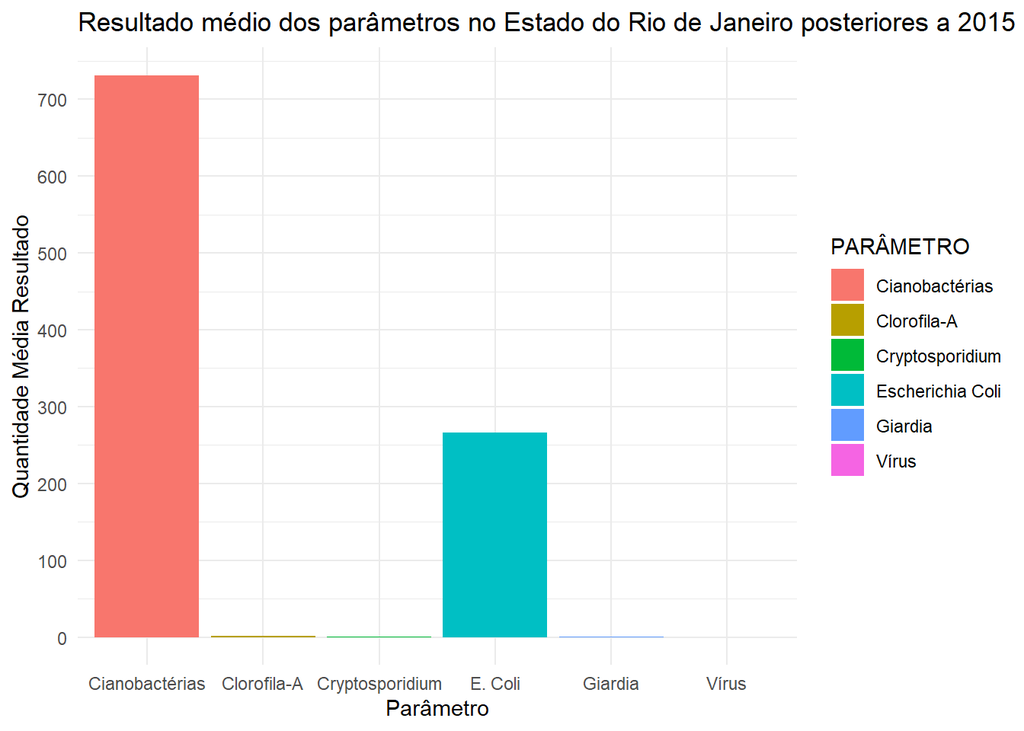

```r
ggplot(data = Analise_resultado) +
  geom_col(mapping = aes(x = PARÂMETRO, y = Média,
                         group = PARÂMETRO, fill = PARÂMETRO),
           position = position_dodge()) +
  labs(x = "Parâmetro", y = "Quantidade Média Resultado", title = "Resultado médio dos parâmetros no Estado do Rio de Janeiro posteriores a 2015") +
  theme_light() +
  scale_y_continuous(n.breaks = 10)+
  scale_x_discrete(labels = c("Cianobactérias" = "Cianobactérias","Clorofila-A" = "Clorofila-A",
  "Cryptosporidium" = "Cryptosporidium","Escherichia Coli" = "E. Coli","Giardia" = "Giardia", "Vírus"="Vírus"))+
  theme_minimal()
```

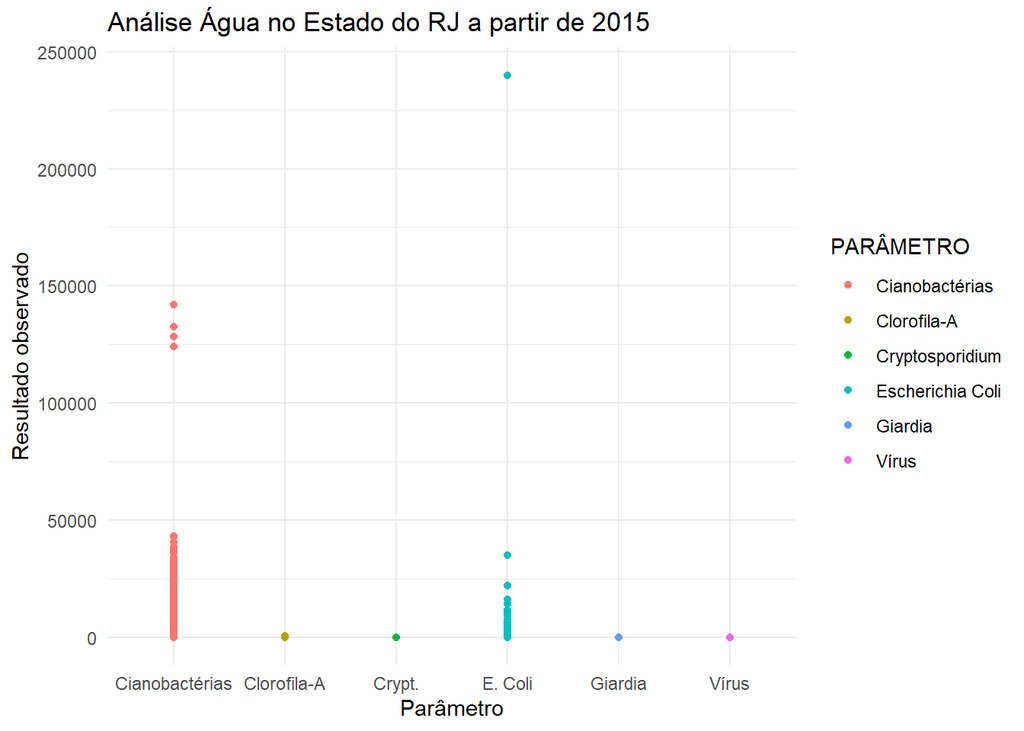

```r
p <- ggplot(analises_agua_RJ_agrupado, aes(x=PARÂMETRO, y=RESULTADO)) +
  geom_point(na.rm = TRUE,aes(colour = PARÂMETRO))+
  labs(x = "Parâmetro", y = "Resultado observado", title = "Análise Água no Estado do RJ a partir de 2015")+
    scale_x_discrete(labels = c("Cianobactérias" = "Cianobactérias","Clorofila-A" = "Clorofila-A",
  "Cryptosporidium" = "Crypt.","Escherichia Coli" = "E. Coli","Giardia" = "Giardia", "Vírus"="Vírus"))+
  theme_minimal()
p
```

- O gráfico permite obervar os valores obtidos como resultado para os parâmetros apresentados

### **Questão 2**

#### Tratamento da **2ª Análise**

-Iremos susbtituir os NA por “Desconhecido”

```r
analises_agua_RJ$CATEGORIA_MANANCIAL_SUP[which(is.na(analises_agua_RJ$CATEGORIA_MANANCIAL_SUP))] <- "Desconhecido"
```

- Deixar a 1ª letra maiuscula das Categorias de Mananciais (*CATEGORIA_MANANCIAL_SUP*)

```r
analises_agua_RJ$CATEGORIA_MANANCIAL_SUP <- str_to_title(analises_agua_RJ$CATEGORIA_MANANCIAL_SUP)
```

- Contando as ocorrências das categorias

```r
analises_agua_RJ_manacial_agp <- count(analises_agua_RJ,CATEGORIA_MANANCIAL_SUP) %>%
                                  arrange(n)
```

- Utilizando um Factor com levels para ordenar as categorias de mananciais no gráfico

```r
analises_agua_RJ_manacial_agp$CATEGORIA_MANANCIAL_SUP <- factor(analises_agua_RJ_manacial_agp$CATEGORIA_MANANCIAL_SUP,
                                                 levels = analises_agua_RJ_manacial_agp$CATEGORIA_MANANCIAL_SUP)
```

### **Questão 3**

#### Gráfico da **2ª Análise**

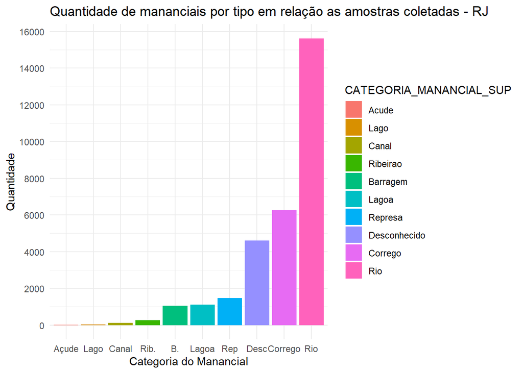

```r
ggplot(data = analises_agua_RJ_manacial_agp) +
  geom_col(mapping = aes(x = CATEGORIA_MANANCIAL_SUP, y = n ,
                         group = CATEGORIA_MANANCIAL_SUP, fill = CATEGORIA_MANANCIAL_SUP),
           position = position_dodge()) +
  labs(x = "Categoria do Manancial", y = "Quantidade", title = "Quantidade de mananciais por tipo em relação as amostras coletadas - RJ") +
  theme_light() +
  scale_y_continuous(n.breaks = 10)+
    scale_x_discrete(labels = c("Acude" = "Açude","Lago" = "Lago",
  "Canal" = "Canal","Ribeirao" = "Rib.","Barragem" = "B.", "Lagoa"="Lagoa","Represa"="Rep","Desconhecido"="Desc", "Corrego"="Corrego","Rio"="Rio"))+
  theme_minimal()
```

- O Gráfico mostra que a maioria das amostras é coletada em rios